# Ask a home buyer to describe their dream house, and they probably won't begin with the height of the basement ceiling or the proximity to an east-west railroad. But this dataset proves that much more influences price negotiations than the number of bedrooms or a white-picket fence.

# With 79 explanatory variables describing (almost) every aspect of residential homes in Ames, Iowa, this competition challenges you to predict the final price of each home.

# Creative feature engineering

# Advanced regression techniques like- Linear Regression

## SalePrice - the property's sale price in dollars. This is the target variable that predict.

```python
import pandas as pd
```

```python
# Importing  the libraries.
import pandas as pd
import numpy as np
from sklearn.datasets import make_classification
import matplotlib.pyplot as plt
import seaborn as sns
%matplotlib inline


import warnings
warnings.filterwarnings('ignore')
```

```python
df=pd.read_csv('train.csv')
```

```python
df.head()
```

|  | Id | MSSubClass | MSZoning | LotFrontage | LotArea | Street | Alley | LotShape | LandContour | Utilities | ... | PoolArea | PoolQC | Fence | MiscFeature | MiscVal | MoSold | YrSold | SaleType | SaleCondition | SalePrice |
| --- | --- | --- | --- | --- | --- | --- | --- | --- | --- | --- | --- | --- | --- | --- | --- | --- | --- | --- | --- | --- | --- |
| 0 | 1 | 60 | RL | 65.0 | 8450 | Pave | NaN | Reg | Lvl | AllPub | ... | 0 | NaN | NaN | NaN | 0 | 2 | 2008 | WD | Normal | 208500 |
| 1 | 2 | 20 | RL | 80.0 | 9600 | Pave | NaN | Reg | Lvl | AllPub | ... | 0 | NaN | NaN | NaN | 0 | 5 | 2007 | WD | Normal | 181500 |
| 2 | 3 | 60 | RL | 68.0 | 11250 | Pave | NaN | IR1 | Lvl | AllPub | ... | 0 | NaN | NaN | NaN | 0 | 9 | 2008 | WD | Normal | 223500 |
| 3 | 4 | 70 | RL | 60.0 | 9550 | Pave | NaN | IR1 | Lvl | AllPub | ... | 0 | NaN | NaN | NaN | 0 | 2 | 2006 | WD | Abnorml | 140000 |
| 4 | 5 | 60 | RL | 84.0 | 14260 | Pave | NaN | IR1 | Lvl | AllPub | ... | 0 | NaN | NaN | NaN | 0 | 12 | 2008 | WD | Normal | 250000 |

5 rows × 81 columns

```python
df.describe()
```

|  | Id | MSSubClass | LotFrontage | LotArea | OverallQual | OverallCond | YearBuilt | YearRemodAdd | MasVnrArea | BsmtFinSF1 | ... | WoodDeckSF | OpenPorchSF | EnclosedPorch | 3SsnPorch | ScreenPorch | PoolArea | MiscVal | MoSold | YrSold | SalePrice |
| --- | --- | --- | --- | --- | --- | --- | --- | --- | --- | --- | --- | --- | --- | --- | --- | --- | --- | --- | --- | --- | --- |
| count | 1460.000000 | 1460.000000 | 1201.000000 | 1460.000000 | 1460.000000 | 1460.000000 | 1460.000000 | 1460.000000 | 1452.000000 | 1460.000000 | ... | 1460.000000 | 1460.000000 | 1460.000000 | 1460.000000 | 1460.000000 | 1460.000000 | 1460.000000 | 1460.000000 | 1460.000000 | 1460.000000 |
| mean | 730.500000 | 56.897260 | 70.049958 | 10516.828082 | 6.099315 | 5.575342 | 1971.267808 | 1984.865753 | 103.685262 | 443.639726 | ... | 94.244521 | 46.660274 | 21.954110 | 3.409589 | 15.060959 | 2.758904 | 43.489041 | 6.321918 | 2007.815753 | 180921.195890 |
| std | 421.610009 | 42.300571 | 24.284752 | 9981.264932 | 1.382997 | 1.112799 | 30.202904 | 20.645407 | 181.066207 | 456.098091 | ... | 125.338794 | 66.256028 | 61.119149 | 29.317331 | 55.757415 | 40.177307 | 496.123024 | 2.703626 | 1.328095 | 79442.502883 |
| min | 1.000000 | 20.000000 | 21.000000 | 1300.000000 | 1.000000 | 1.000000 | 1872.000000 | 1950.000000 | 0.000000 | 0.000000 | ... | 0.000000 | 0.000000 | 0.000000 | 0.000000 | 0.000000 | 0.000000 | 0.000000 | 1.000000 | 2006.000000 | 34900.000000 |
| 25% | 365.750000 | 20.000000 | 59.000000 | 7553.500000 | 5.000000 | 5.000000 | 1954.000000 | 1967.000000 | 0.000000 | 0.000000 | ... | 0.000000 | 0.000000 | 0.000000 | 0.000000 | 0.000000 | 0.000000 | 0.000000 | 5.000000 | 2007.000000 | 129975.000000 |
| 50% | 730.500000 | 50.000000 | 69.000000 | 9478.500000 | 6.000000 | 5.000000 | 1973.000000 | 1994.000000 | 0.000000 | 383.500000 | ... | 0.000000 | 25.000000 | 0.000000 | 0.000000 | 0.000000 | 0.000000 | 0.000000 | 6.000000 | 2008.000000 | 163000.000000 |
| 75% | 1095.250000 | 70.000000 | 80.000000 | 11601.500000 | 7.000000 | 6.000000 | 2000.000000 | 2004.000000 | 166.000000 | 712.250000 | ... | 168.000000 | 68.000000 | 0.000000 | 0.000000 | 0.000000 | 0.000000 | 0.000000 | 8.000000 | 2009.000000 | 214000.000000 |
| max | 1460.000000 | 190.000000 | 313.000000 | 215245.000000 | 10.000000 | 9.000000 | 2010.000000 | 2010.000000 | 1600.000000 | 5644.000000 | ... | 857.000000 | 547.000000 | 552.000000 | 508.000000 | 480.000000 | 738.000000 | 15500.000000 | 12.000000 | 2010.000000 | 755000.000000 |

8 rows × 38 columns

```python
df['MSSubClass'].isnull().sum()
```

```
0
```

```python
df['MSSubClass'].unique()
```

```
array([ 60,  20,  70,  50, 190,  45,  90, 120,  30,  85,  80, 160,  75,
       180,  40], dtype=int64)
```

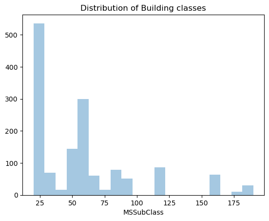

```python
sns.distplot(df['MSSubClass'],kde=False)
plt.title ('Distribution of Building classes')
plt.show()
```

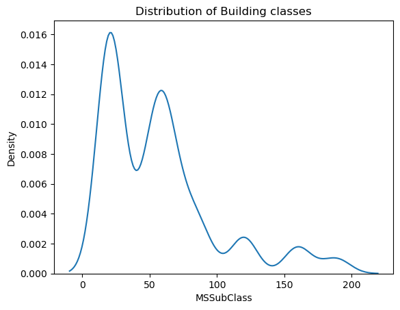

```python
sns.distplot(df['MSSubClass'],hist=False)
plt.title ('Distribution of Building classes')
plt.show()
```

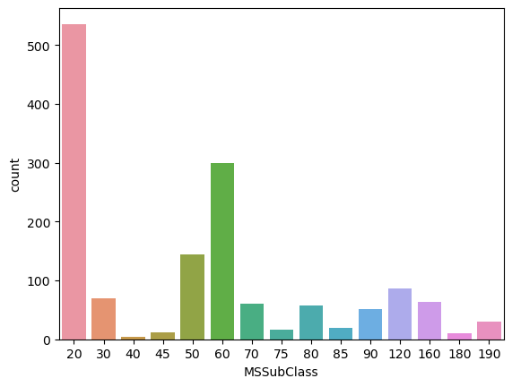

```python
sns.countplot(x='MSSubClass', data=df)
plt.show()
```

.Class 20 has the highest counts(more than 500) followed by the class 60(300). .Least count is of 40 class.

```python
df['MSZoning'].unique()
```

```
array(['RL', 'RM', 'C (all)', 'FV', 'RH'], dtype=object)
```

```python
df.MSZoning.isnull().sum()
```

```
0
```

```python
df['MSZoning'].value_counts()
```

```
RL         1151
RM          218
FV           65
RH           16
C (all)      10
Name: MSZoning, dtype: int64
```

[figure not shown]

```python
x=[115 , 218 ,65, 16 , 10]
y=['RL','RM','FV','RH','C (all)']
ex=[0.0, 0.0, 0.0, 0.0, 0.3]
plt.pie(x,labels=y,explode=ex,autopct='%0.1f%%',radius=1,startangle=180,shadow=True,textprops={'fontsize':12},labeldistance=1.1)
plt.title('Percentage wise category distribution')
plt.legend()
plt.show()
```

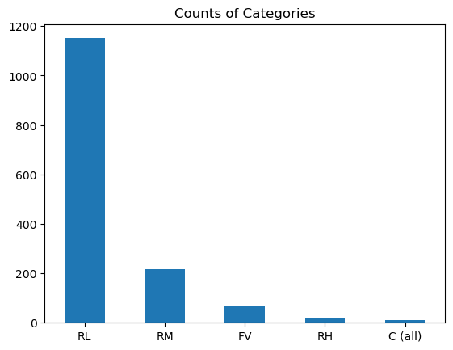

```python
df['MSZoning'].value_counts().plot(kind='bar')
plt.title('Counts of Categories')
plt.xticks(rotation=360)
plt.show()
```

RL has the highest number of counts. C(all) has the least number of counts.

```python
df['LotFrontage'].isnull().sum()
```

```
259
```

```python
df['LotFrontage'].describe()
```

```
count    1201.000000
mean       70.049958
std        24.284752
min        21.000000
25%        59.000000
50%        69.000000
75%        80.000000
max       313.000000
Name: LotFrontage, dtype: float64
```

```python
df[df.LotFrontage.isnull()]
```

|  | Id | MSSubClass | MSZoning | LotFrontage | LotArea | Street | Alley | LotShape | LandContour | Utilities | ... | PoolArea | PoolQC | Fence | MiscFeature | MiscVal | MoSold | YrSold | SaleType | SaleCondition | SalePrice |
| --- | --- | --- | --- | --- | --- | --- | --- | --- | --- | --- | --- | --- | --- | --- | --- | --- | --- | --- | --- | --- | --- |
| 7 | 8 | 60 | RL | NaN | 10382 | Pave | NaN | IR1 | Lvl | AllPub | ... | 0 | NaN | NaN | Shed | 350 | 11 | 2009 | WD | Normal | 200000 |
| 12 | 13 | 20 | RL | NaN | 12968 | Pave | NaN | IR2 | Lvl | AllPub | ... | 0 | NaN | NaN | NaN | 0 | 9 | 2008 | WD | Normal | 144000 |
| 14 | 15 | 20 | RL | NaN | 10920 | Pave | NaN | IR1 | Lvl | AllPub | ... | 0 | NaN | GdWo | NaN | 0 | 5 | 2008 | WD | Normal | 157000 |
| 16 | 17 | 20 | RL | NaN | 11241 | Pave | NaN | IR1 | Lvl | AllPub | ... | 0 | NaN | NaN | Shed | 700 | 3 | 2010 | WD | Normal | 149000 |
| 24 | 25 | 20 | RL | NaN | 8246 | Pave | NaN | IR1 | Lvl | AllPub | ... | 0 | NaN | MnPrv | NaN | 0 | 5 | 2010 | WD | Normal | 154000 |
| ... | ... | ... | ... | ... | ... | ... | ... | ... | ... | ... | ... | ... | ... | ... | ... | ... | ... | ... | ... | ... | ... |
| 1429 | 1430 | 20 | RL | NaN | 12546 | Pave | NaN | IR1 | Lvl | AllPub | ... | 0 | NaN | NaN | NaN | 0 | 4 | 2007 | WD | Normal | 182900 |
| 1431 | 1432 | 120 | RL | NaN | 4928 | Pave | NaN | IR1 | Lvl | AllPub | ... | 0 | NaN | NaN | NaN | 0 | 10 | 2009 | WD | Normal | 143750 |
| 1441 | 1442 | 120 | RM | NaN | 4426 | Pave | NaN | Reg | Lvl | AllPub | ... | 0 | NaN | NaN | NaN | 0 | 5 | 2008 | WD | Normal | 149300 |
| 1443 | 1444 | 30 | RL | NaN | 8854 | Pave | NaN | Reg | Lvl | AllPub | ... | 0 | NaN | NaN | NaN | 0 | 5 | 2009 | WD | Normal | 121000 |
| 1446 | 1447 | 20 | RL | NaN | 26142 | Pave | NaN | IR1 | Lvl | AllPub | ... | 0 | NaN | NaN | NaN | 0 | 4 | 2010 | WD | Normal | 157900 |

259 rows × 81 columns

```python
df[['LotArea','LotFrontage']][df.LotFrontage.isnull()]
```

|  | LotArea | LotFrontage |
| --- | --- | --- |
| 7 | 10382 | NaN |
| 12 | 12968 | NaN |
| 14 | 10920 | NaN |
| 16 | 11241 | NaN |
| 24 | 8246 | NaN |
| ... | ... | ... |
| 1429 | 12546 | NaN |
| 1431 | 4928 | NaN |
| 1441 | 4426 | NaN |
| 1443 | 8854 | NaN |
| 1446 | 26142 | NaN |

259 rows × 2 columns

```python
df['LotFrontage'].mean()
```

```
70.04995836802665
```

```python
df['LotFrontage']=df['LotFrontage'].fillna(70)
# N pattern found, fill the missing value with mean.
```

```python
df['LotFrontage'].isnull().sum()
```

```
0
```

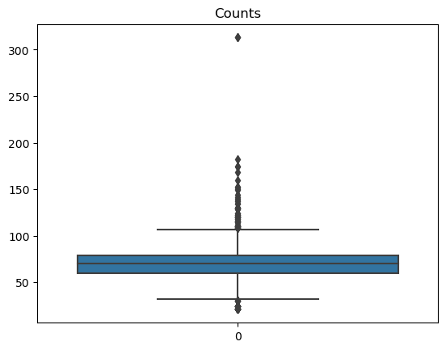

```python
sns.boxplot(df['LotFrontage'])
plt.title('Counts')
plt.show()
```

```python
df['Street'].unique()
```

```
array(['Pave', 'Grvl'], dtype=object)
```

```python
df['Street'].isnull().sum()
```

```
0
```

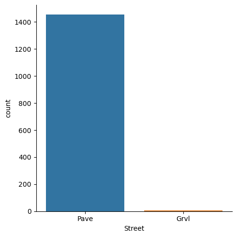

```python
sns.catplot(x='Street',data=df,kind='count')
plt.show()
```

Mostely use Pave road category

```python
df.Alley.unique()
```

```
array([nan, 'Grvl', 'Pave'], dtype=object)
```

```python
df.Alley.isnull().sum()
```

```
1369
```

```python
df.Alley.value_counts()
```

```
Grvl    50
Pave    41
Name: Alley, dtype: int64
```

Since no specific pattern found regarding alley, so we create a new for all th missing values

```python
df['Alley']=df.Alley.fillna('No Alley')
```

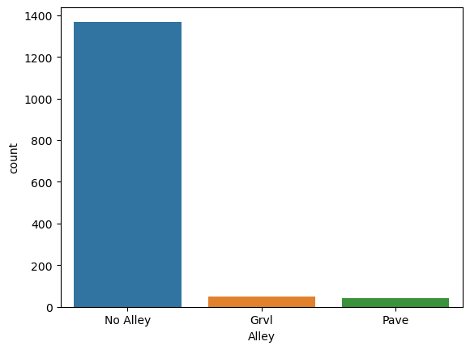

```python
sns.countplot(x='Alley',data=df)
plt.show()
```

As from the above plot we can conclude that there are more value of No alley.

```python
df['LotShape'].unique()
```

```
array(['Reg', 'IR1', 'IR2', 'IR3'], dtype=object)
```

```python
df['LotShape'].isnull().sum()
```

```
0
```

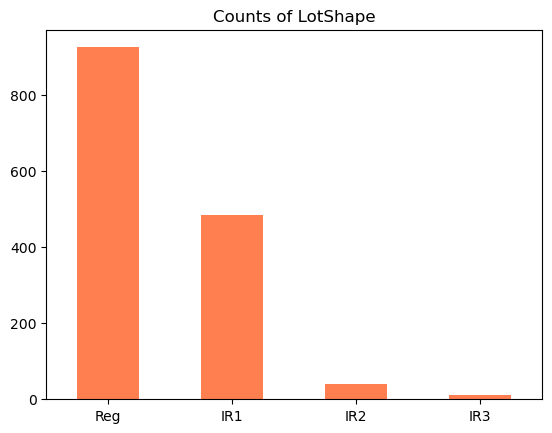

```python
df['LotShape'].value_counts().plot(kind='bar',color='coral')
plt.title('Counts of LotShape')
plt.xticks(rotation=360)
plt.show()
```

Column LordShape has the highest number of category Reg

```python
df.columns
```

```
Index(['Id', 'MSSubClass', 'MSZoning', 'LotFrontage', 'LotArea', 'Street',
       'Alley', 'LotShape', 'LandContour', 'Utilities', 'LotConfig',
       'LandSlope', 'Neighborhood', 'Condition1', 'Condition2', 'BldgType',
       'HouseStyle', 'OverallQual', 'OverallCond', 'YearBuilt', 'YearRemodAdd',
       'RoofStyle', 'RoofMatl', 'Exterior1st', 'Exterior2nd', 'MasVnrType',
       'MasVnrArea', 'ExterQual', 'ExterCond', 'Foundation', 'BsmtQual',
       'BsmtCond', 'BsmtExposure', 'BsmtFinType1', 'BsmtFinSF1',
       'BsmtFinType2', 'BsmtFinSF2', 'BsmtUnfSF', 'TotalBsmtSF', 'Heating',
       'HeatingQC', 'CentralAir', 'Electrical', '1stFlrSF', '2ndFlrSF',
       'LowQualFinSF', 'GrLivArea', 'BsmtFullBath', 'BsmtHalfBath', 'FullBath',
       'HalfBath', 'BedroomAbvGr', 'KitchenAbvGr', 'KitchenQual',
       'TotRmsAbvGrd', 'Functional', 'Fireplaces', 'FireplaceQu', 'GarageType',
       'GarageYrBlt', 'GarageFinish', 'GarageCars', 'GarageArea', 'GarageQual',
       'GarageCond', 'PavedDrive', 'WoodDeckSF', 'OpenPorchSF',
       'EnclosedPorch', '3SsnPorch', 'ScreenPorch', 'PoolArea', 'PoolQC',
       'Fence', 'MiscFeature', 'MiscVal', 'MoSold', 'YrSold', 'SaleType',
       'SaleCondition', 'SalePrice'],
      dtype='object')
```

```python
df['LandContour'].unique()
```

```
array(['Lvl', 'Bnk', 'Low', 'HLS'], dtype=object)
```

```python
df['LandContour'].value_counts()
```

```
Lvl    1311
Bnk      63
HLS      50
Low      36
Name: LandContour, dtype: int64
```

```python
df['LandContour'].isnull().sum()
```

```
0
```

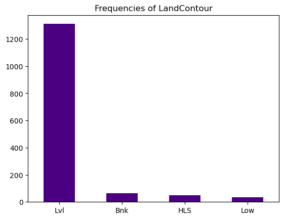

```python
df['LandContour'].value_counts().plot(kind='bar',color='indigo')
plt.title('Frequencies of LandContour')
plt.xticks(rotation=360)
plt.show()
```

LandContour(flatness of the property is more in the Lvl category

```python
df['Utilities'].unique()
```

```
array(['AllPub', 'NoSeWa'], dtype=object)
```

```python
df['Utilities'].value_counts()
```

```
AllPub    1459
NoSeWa       1
Name: Utilities, dtype: int64
```

```python
df['Utilities'].isnull().sum()
```

```
0
```

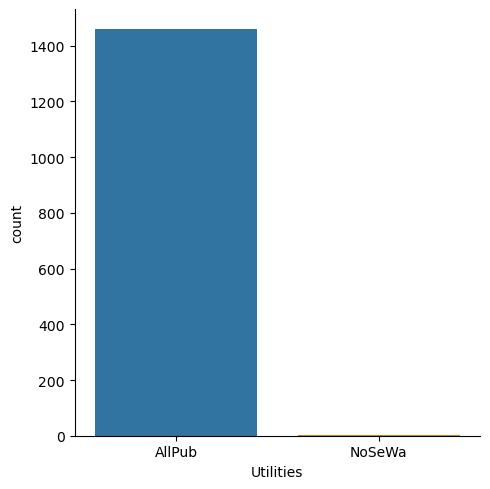

```python
sns.catplot(x='Utilities',data=df,kind='count')
plt.show()
```

utilities AllPub has the heighest count

```python
df['LotConfig'].unique()
```

```
array(['Inside', 'FR2', 'Corner', 'CulDSac', 'FR3'], dtype=object)
```

```python
df['LotConfig'].isnull().sum()
```

```
0
```

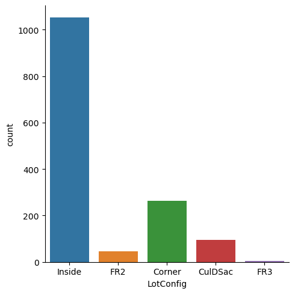

```python
  sns.catplot(x='LotConfig',data=df,kind='count')
plt.show()
```

```python
df['LandSlope'].unique()
```

```
array(['Gtl', 'Mod', 'Sev'], dtype=object)
```

```python
df['LandSlope'].isnull().sum()
```

```
0
```

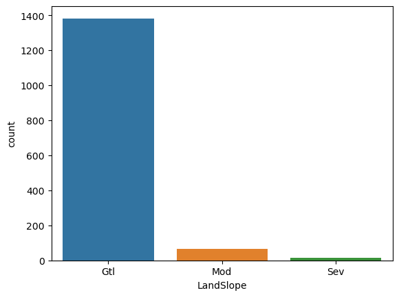

```python
sns.countplot(x='LandSlope', data=df)
plt.show()
```

Highest count of LandSlope(slope of property) is Gtl.

```python
df['Neighborhood'].unique()
```

```
array(['CollgCr', 'Veenker', 'Crawfor', 'NoRidge', 'Mitchel', 'Somerst',
       'NWAmes', 'OldTown', 'BrkSide', 'Sawyer', 'NridgHt', 'NAmes',
       'SawyerW', 'IDOTRR', 'MeadowV', 'Edwards', 'Timber', 'Gilbert',
       'StoneBr', 'ClearCr', 'NPkVill', 'Blmngtn', 'BrDale', 'SWISU',
       'Blueste'], dtype=object)
```

```python
df['Neighborhood'].isnull().sum()
```

```
0
```

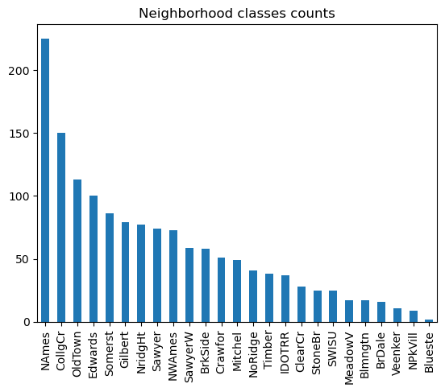

```python
df['Neighborhood'].value_counts().plot(kind='bar')
plt.title('Neighborhood classes counts')
plt.show()
```

NAmes has the heighest number of counts Neighborhood(physical location with in Amies cities limit)

```python
df['Condition1'].unique()
```

```
array(['Norm', 'Feedr', 'PosN', 'Artery', 'RRAe', 'RRNn', 'RRAn', 'PosA',
       'RRNe'], dtype=object)
```

```python
df['Condition1'].isnull().sum()
```

```
0
```

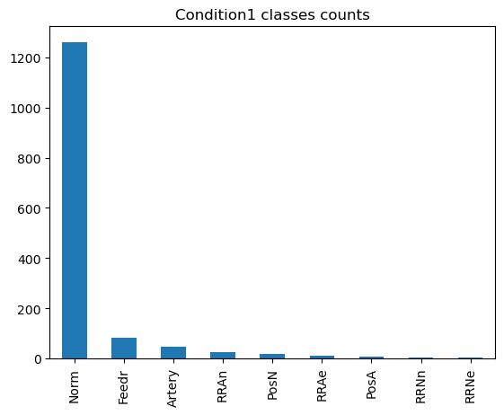

```python
df['Condition1'].value_counts().plot(kind='bar')
plt.title('Condition1 classes counts')
plt.show()
```

Norm(proximity to main road or railroad) has the counts.

```python
df['Condition2'].unique()
```

```
array(['Norm', 'Artery', 'RRNn', 'Feedr', 'PosN', 'PosA', 'RRAn', 'RRAe'],
      dtype=object)
```

```python
df['Condition2'].isnull().sum()
```

```
0
```

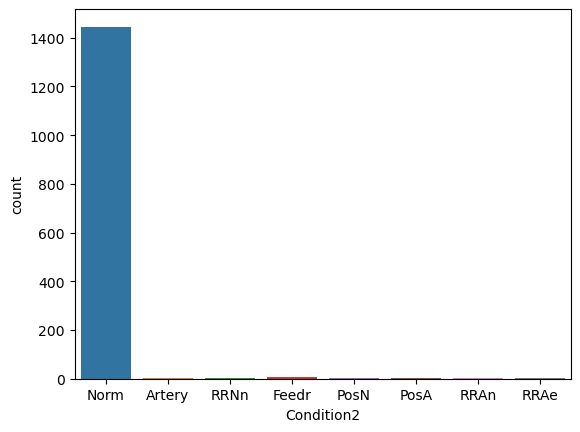

```python
sns.countplot(x='Condition2', data=df)
plt.show()
```

```python
df['BldgType'].unique()
```

```
array(['1Fam', '2fmCon', 'Duplex', 'TwnhsE', 'Twnhs'], dtype=object)
```

```python
df['BldgType'].isnull().sum()
```

```
0
```

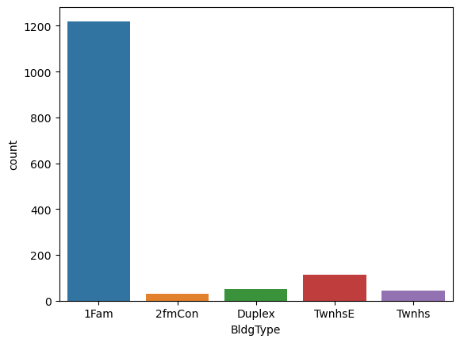

```python
sns.countplot(x='BldgType', data=df)
plt.show()
```

Building type 1Fam has the highest number of counts. Least number of Building type counts is of 2fmCon.

```python
df['HouseStyle'].unique()
```

```
array(['2Story', '1Story', '1.5Fin', '1.5Unf', 'SFoyer', 'SLvl', '2.5Unf',
       '2.5Fin'], dtype=object)
```

```python
df['HouseStyle'].isnull().sum()
```

```
0
```

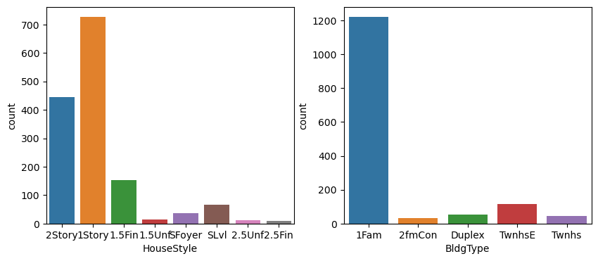

```python
plt.figure(figsize=(10,4))
plt.subplot(1,2,1)
sns.countplot(x='HouseStyle', data=df)

plt.subplot(1,2,2)
sns.countplot(x='BldgType', data=df)
plt.show()
```

```python
l1=['HouseStyle', 'OverallQual', 'OverallCond', 'RoofStyle', 'RoofMatl', 'Exterior1st', 'Exterior2nd']
```

```python
list(enumerate(l1))
```

```
[(0, 'HouseStyle'),
 (1, 'OverallQual'),
 (2, 'OverallCond'),
 (3, 'RoofStyle'),
 (4, 'RoofMatl'),
 (5, 'Exterior1st'),
 (6, 'Exterior2nd')]
```

```python
# plt.figure(figsize=(10,7))
# for i in enumerate(l1):
#     plt.subplot(3,3, i[0]+1)
#     sns.countplot(i[1], data=df)
#     plt.xticks(rotation=45)
```

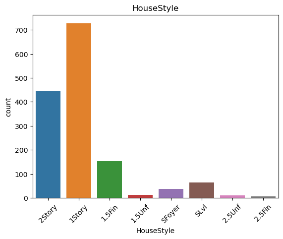

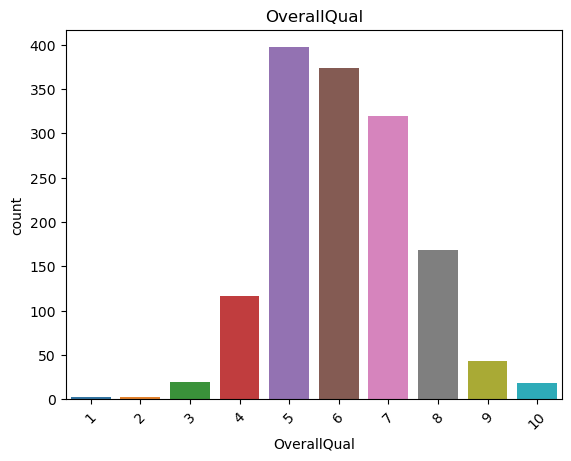

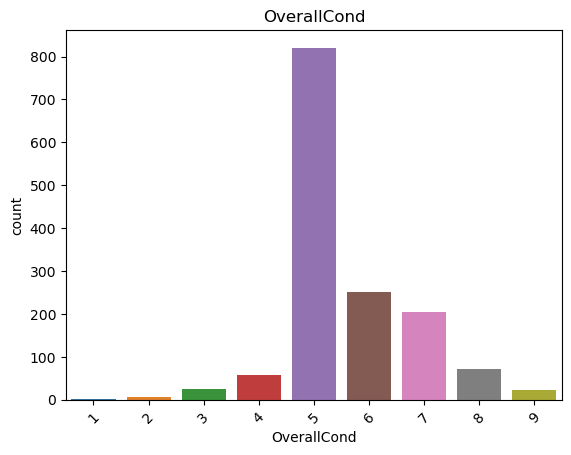

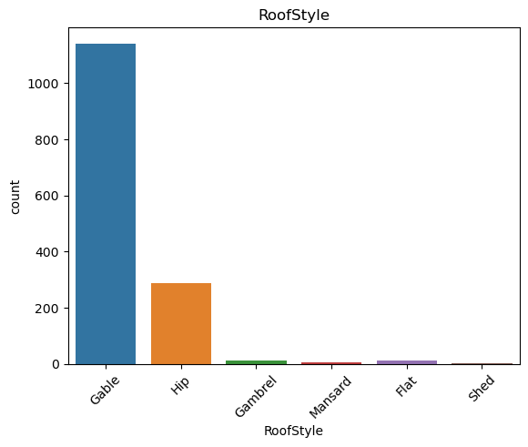

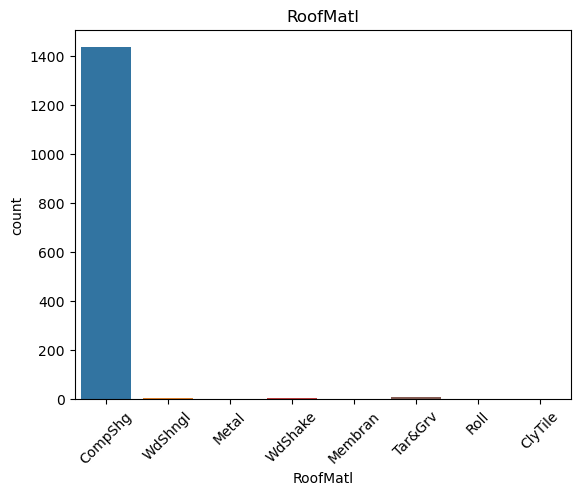

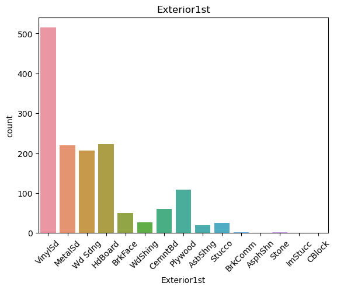

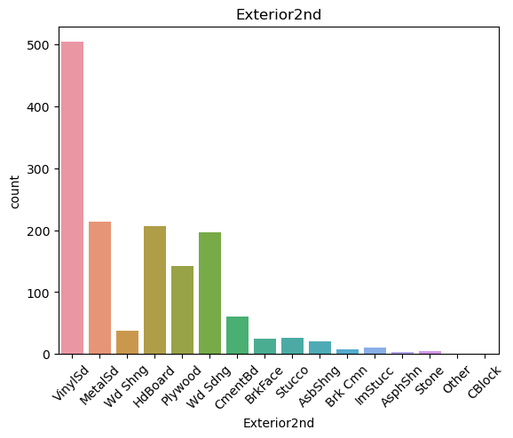

```python
for i in l1:
    sns.countplot(x=i, data=df)
    plt.title(i)
    plt.xticks(rotation=45)
    plt.show()
    print('**************************************')
```

```python
 df['MasVnrType'].unique()
```

```
array(['BrkFace', 'None', 'Stone', 'BrkCmn', nan], dtype=object)
```

```python
df['MasVnrType'].isnull().sum()
```

```
8
```

```python
df['MasVnrArea'].isnull().sum()
```

```
8
```

```python
df[['MasVnrType', 'MasVnrArea']][df.MasVnrArea==0]
```

|  | MasVnrType | MasVnrArea |
| --- | --- | --- |
| 1 | None | 0.0 |
| 3 | None | 0.0 |
| 5 | None | 0.0 |
| 8 | None | 0.0 |
| 9 | None | 0.0 |
| ... | ... | ... |
| 1454 | None | 0.0 |
| 1455 | None | 0.0 |
| 1457 | None | 0.0 |
| 1458 | None | 0.0 |
| 1459 | None | 0.0 |

861 rows × 2 columns

```python
df['MasVnrType']=df['MasVnrType'].fillna('None')
```

```python
df['MasVnrArea']=df['MasVnrArea'].fillna(0)
```

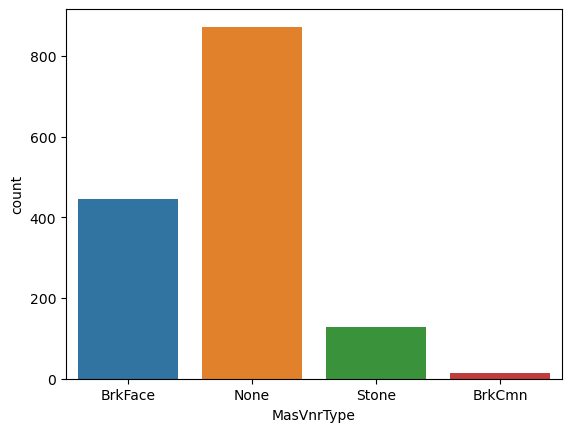

```python
sns.countplot(x='MasVnrType', data=df)
plt.show()
```

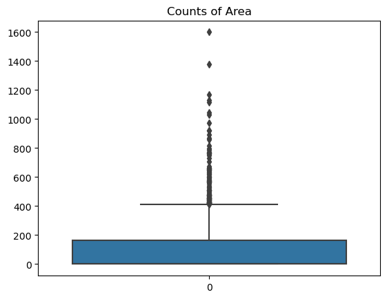

```python
sns.boxplot(df['MasVnrArea'])
plt.title('Counts of Area')
plt.show()
```

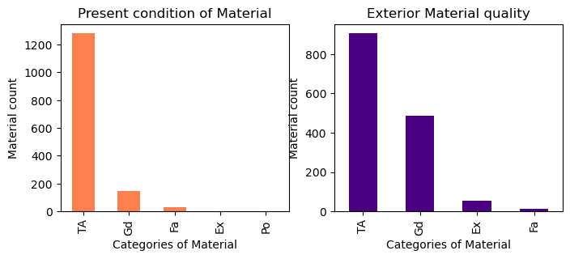

```python
plt.figure(figsize=(8,3))
plt.subplot(1,2,1)
df['ExterCond'].value_counts().plot(kind='bar',color='coral')
plt.title('Present condition of Material')
plt.xlabel('Categories of Material')
plt.ylabel('Material count')


plt.subplot(1,2,2)
df['ExterQual'].value_counts().plot(kind='bar',color='indigo')
plt.title('Exterior Material quality')
plt.xlabel('Categories of Material')
plt.ylabel('Material count')

plt.show()
```

ExterQual: Exterior material quality has the highest in category TA ExterCond :: Present condition of the material on the exterior is highest in TA

```python
df['Foundation'].unique()
```

```
array(['PConc', 'CBlock', 'BrkTil', 'Wood', 'Slab', 'Stone'], dtype=object)
```

```python
df['Foundation'].isnull().sum()
```

```
0
```

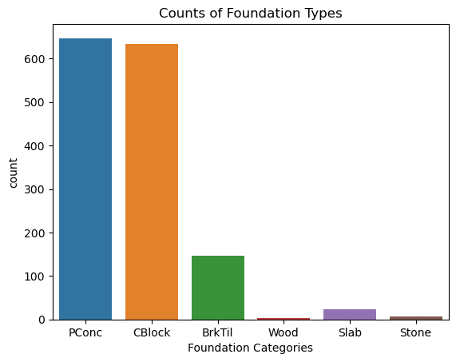

```python
sns.countplot(x='Foundation', data=df)
plt.title('Counts of Foundation Types')
plt.xlabel('Foundation Categories')
plt.show()
```

From the above graph we conclude that Foundation category(PConc) has the highest counts, followed by the CBlock.

```python
df.BsmtExposure.isnull().sum()
```

```
38
```

```python
df[['BsmtQual','BsmtCond', 'BsmtExposure', 'BsmtFinType1', 'BsmtFinSF1',
       'BsmtFinType2', 'BsmtFinSF2', 'BsmtUnfSF', 'TotalBsmtSF']][df.BsmtExposure.isnull()].head()
```

[output not shown]

```python
df['BsmtQual']=df['BsmtQual'].fillna('NoQuality')
df['BsmtCond']=df['BsmtCond'].fillna('Invalid')
df['BsmtFinType1']=df['BsmtFinType1'].fillna(0)
df['BsmtFinType2']=df['BsmtFinType2'].fillna(0)
df['BsmtExposure']=df['BsmtExposure'].fillna('No')
```

# area does not exist so we can fill the values acording to their data.

```python
df['BsmtQual'].unique()
```

```
array(['Gd', 'TA', 'Ex', 'NoQuality', 'Fa'], dtype=object)
```

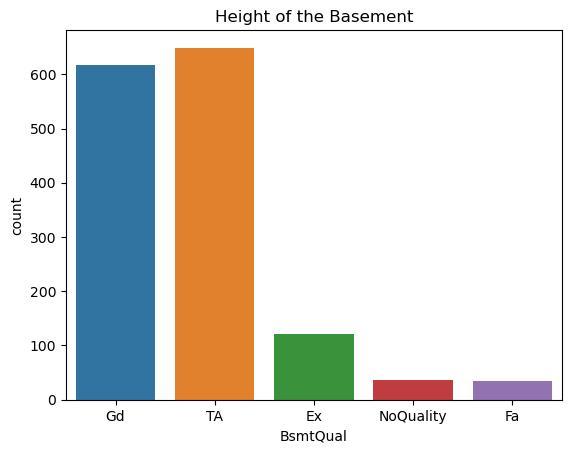

```python
sns.countplot(x='BsmtQual',data=df)
plt.title('Height of the Basement')
plt.show()
```

Basement height TA has the highest count

```python
df['BsmtCond'].unique()
```

```
array(['TA', 'Gd', 'Invalid', 'Fa', 'Po'], dtype=object)
```

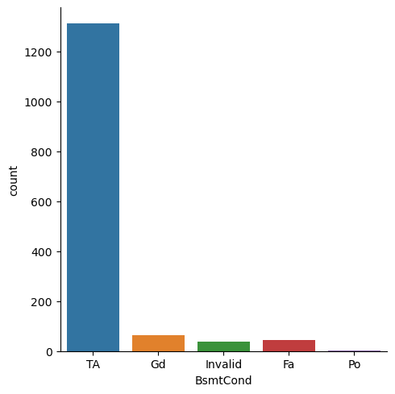

```python
sns.catplot(x='BsmtCond',data=df,kind='count')
plt.show()
```

BsmtCond: General condition of the basement TA has the highest count

```python
df['BsmtExposure'].unique()
```

```
array(['No', 'Gd', 'Mn', 'Av'], dtype=object)
```

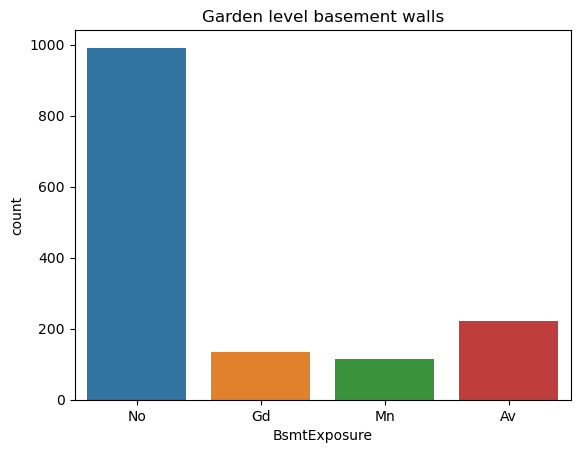

```python
sns.countplot(x='BsmtExposure',data=df)
plt.title('Garden level basement walls')
plt.show()
```

BsmtExposure: Walkout or garden level basement walls...No has the highest copunt

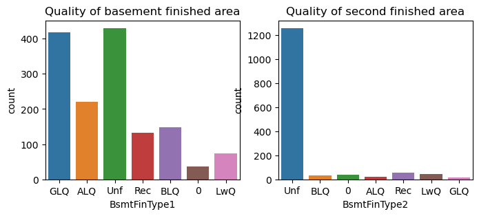

```python
plt.figure(figsize=(8,3))
plt.subplot(1,2,1)
sns.countplot(x='BsmtFinType1',data=df)
plt.title('Quality of basement finished area')

plt.subplot(1,2,2)
sns.countplot(x='BsmtFinType2',data=df)
plt.title('Quality of second finished area')
plt.show()
```

```python
#BsmtFinType1: Quality of basement finished area
#BsmtFinType2: Quality of second finished area
```

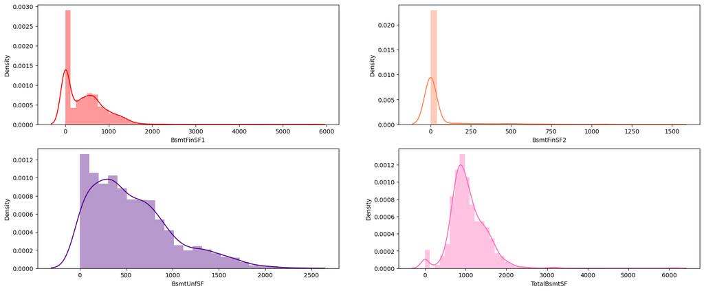

```python
plt.figure(figsize=(20,8))
plt.subplot(2,2,1)
sns.distplot(df['BsmtFinSF1'],color='red')

plt.subplot(2,2,2)
sns.distplot(df['BsmtFinSF2'],color='coral')

plt.subplot(2,2,3)
sns.distplot(df['BsmtUnfSF'],color='indigo')

plt.subplot(2,2,4)
sns.distplot(df['TotalBsmtSF'],color='hotpink')
plt.show()
```

BsmtFinSF1: Type 1 finished square feet BsmtFinSF2: Type 2 finished square feet BsmtUnfSF: Unfinished square feet of basement area TotalBsmtSF: Total square feet of basement area

```python
df['Electrical'].unique()
```

```
array(['SBrkr', 'FuseF', 'FuseA', 'FuseP', 'Mix', nan], dtype=object)
```

```python
df['Electrical'].isnull().sum()
```

```
1
```

```python
df['Electrical'].value_counts()
```

```
SBrkr    1334
FuseA      94
FuseF      27
FuseP       3
Mix         1
Name: Electrical, dtype: int64
```

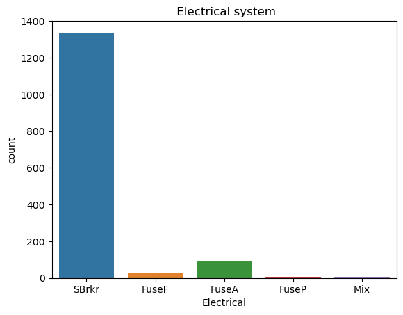

```python
sns.countplot(x='Electrical',data=df)
plt.title(' Electrical system')
plt.show()
```

```python
df['Heating'].unique()
```

```
array(['GasA', 'GasW', 'Grav', 'Wall', 'OthW', 'Floor'], dtype=object)
```

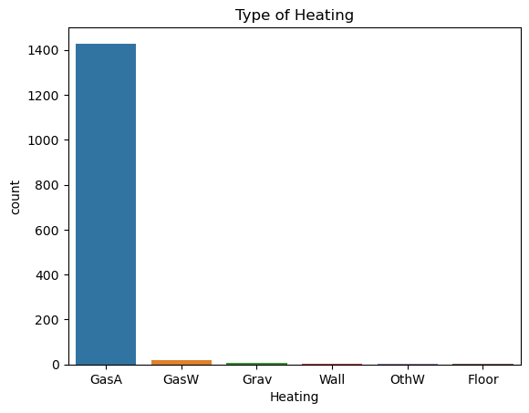

```python
sns.countplot(x='Heating',data =df)
plt.title('Type of Heating')
plt.show()
```

GasA-Gas forced warm air furnace has the highest count of type of heating

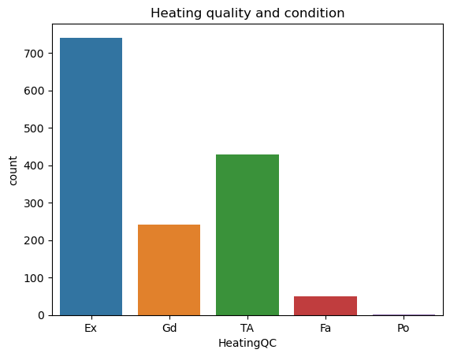

```python
sns.countplot(x='HeatingQC',data =df)
plt.title('Heating quality and condition')
plt.show()
```

# Heating quality and condition

Ex-Excellent has the highest count

Central air conditioning- Yes

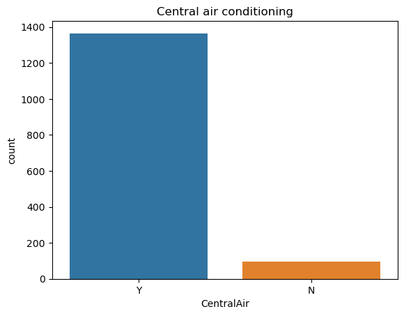

```python
sns.countplot(x='CentralAir',data =df)
plt.title('Central air conditioning')
plt.show()
```

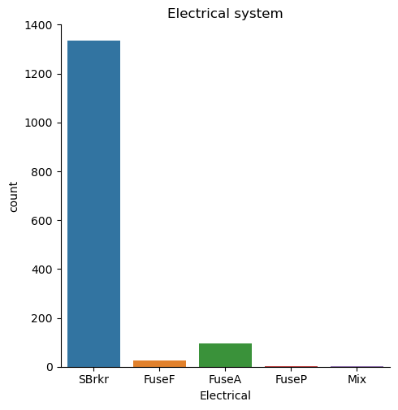

```python
sns.catplot(x='Electrical',data=df,kind='count')
plt.title('Electrical system')
plt.show()
```

SBrk-Standard Circuit Breakers & Romex has the highest count

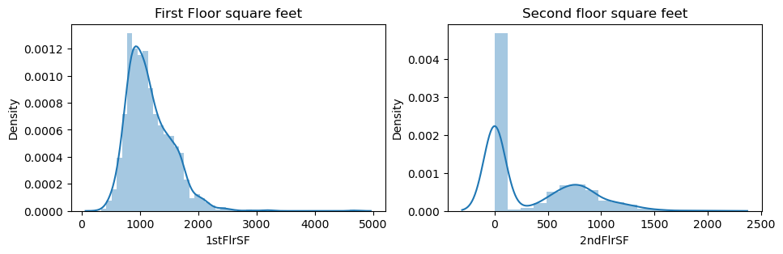

```python
plt.figure(figsize=(11,3))
plt.subplot(1,2,1)
sns.distplot(df['1stFlrSF'])
plt.title('First Floor square feet')

plt.subplot(1,2,2)
sns.distplot(df['2ndFlrSF'])
plt.title('Second floor square feet')
plt.show()
```

# 1stFlrSF: First Floor square feet- From the above graph the distribution is high value at 1000